# Statistical Analysis [DANTES]

Railana Santana

# 1. Data Preparation

This analysis compares the number of test smell occurrences before and after refactoring with DANTES across ten open-source Java projects.

Data import:

```r
BEFORE <- list(
  Accumulo   = c(3644, 10, 460, 1, 186, 128, 28, 1185, 41, 6, 49),
  AMDP       = c(175, 0, 39, 0, 6, 15, 0, 21, 14, 0, 0),
  Bookkeeper = c(4958, 189, 866, 2, 1175, 262, 92, 2885, 280, 15, 33),
  Cassandra  = c(8790, 54, 2089, 0, 1219, 158, 490, 13216, 301, 80, 69),
  Cayenne    = c(4180, 0, 232, 1, 65, 72, 6, 1238, 72, 0, 22),
  CXF        = c(11045, 128, 1043, 8, 1724, 271, 158, 4088, 404, 27, 14),
  DBLE       = c(815, 2, 66, 4, 8, 2, 31, 472, 0, 19, 1),
  Hive       = c(11104, 66, 1404, 5, 716, 283, 118, 5167, 92, 191, 183),
  Kapua      = c(431, 12, 295, 0, 491, 830, 10, 230, 1, 3, 2),
  Wicket     = c(3709, 14, 554, 0, 176, 73, 7, 1032, 25, 17, 52)
)

AFTER <- list(
  Accumulo   = c(903, 7, 180, 0, 114, 27, 16, 673, 35, 0, 15),
  AMDP       = c(50, 0, 12, 0, 3, 14, 0, 15, 10, 0, 0),
  Bookkeeper = c(1861, 103, 412, 2, 727, 77, 73, 1837, 241, 3, 14),
  Cassandra  = c(3467, 48, 1281, 0, 986, 55, 440, 11589, 255, 33, 28),
  Cayenne    = c(319, 0, 52, 0, 52, 12, 3, 708, 68, 0, 4),
  CXF        = c(2096, 85, 161, 5, 1152, 47, 120, 2232, 278, 1, 6),
  DBLE       = c(91, 1, 4, 4, 4, 2, 29, 276, 0, 15, 0),
  Hive       = c(4361, 50, 552, 1, 479, 95, 93, 3318, 82, 63, 38),
  Kapua      = c(21, 9, 99, 0, 81, 76, 6, 61, 0, 0, 0),
  Wicket     = c(1072, 14, 195, 0, 149, 9, 5, 532, 23, 2, 33)
)
```

Visualizing project data BEFORE and AFTER:

```r
print(AFTER)
```

```
## $Accumulo
##  [1] 903   7 180   0 114  27  16 673  35   0  15
##
## $AMDP
##  [1] 50  0 12  0  3 14  0 15 10  0  0
##
## $Bookkeeper
##  [1] 1861  103  412    2  727   77   73 1837  241    3   14
##
## $Cassandra
##  [1]  3467    48  1281     0   986    55   440 11589   255    33    28
##
## $Cayenne
##  [1] 319   0  52   0  52  12   3 708  68   0   4
##
## $CXF
##  [1] 2096   85  161    5 1152   47  120 2232  278    1    6
##
## $DBLE
##  [1]  91   1   4   4   4   2  29 276   0  15   0
##
## $Hive
##  [1] 4361   50  552    1  479   95   93 3318   82   63   38
##
## $Kapua
##  [1] 21  9 99  0 81 76  6 61  0  0  0
##
## $Wicket
##  [1] 1072   14  195    0  149    9    5  532   23    2   33
```

```r
print(BEFORE)
```

```
## $Accumulo
##  [1] 3644   10  460    1  186  128   28 1185   41    6   49
##
## $AMDP
##  [1] 175   0  39   0   6  15   0  21  14   0   0
##
## $Bookkeeper
##  [1] 4958  189  866    2 1175  262   92 2885  280   15   33
##
## $Cassandra
##  [1]  8790    54  2089     0  1219   158   490 13216   301    80    69
##
## $Cayenne
##  [1] 4180    0  232    1   65   72    6 1238   72    0   22
##
## $CXF
##  [1] 11045   128  1043     8  1724   271   158  4088   404    27    14
##
## $DBLE
##  [1] 815   2  66   4   8   2  31 472   0  19   1
##
## $Hive
##  [1] 11104    66  1404     5   716   283   118  5167    92   191   183
##
## $Kapua
##  [1] 431  12 295   0 491 830  10 230   1   3   2
##
## $Wicket
##  [1] 3709   14  554    0  176   73    7 1032   25   17   52
```

# 2. Descriptive Analysis

We first calculate the total number of test smell occurrences for each project.

```r
before <- sapply(BEFORE, sum)
after <- sapply(AFTER, sum)

diference <- before - after

reduction <- (diference / before) * 100

results <- data.frame(
  Project = names(before),
  Before = as.numeric(before),
  After = as.numeric(after),
  Difference = as.numeric(diference),
  Reduction = round(as.numeric(reduction), 2)
)

knitr::kable(
  results,
  caption = "Test smell reduction by project."
)
```

Test smell reduction by project.

| Project | Before | After | Difference | Reduction |
| --- | --- | --- | --- | --- |
| Accumulo | 5738 | 1970 | 3768 | 65.67 |
| AMDP | 270 | 104 | 166 | 61.48 |
| Bookkeeper | 10757 | 5350 | 5407 | 50.26 |
| Cassandra | 26466 | 18182 | 8284 | 31.30 |
| Cayenne | 5888 | 1218 | 4670 | 79.31 |
| CXF | 18910 | 6183 | 12727 | 67.30 |
| DBLE | 1420 | 426 | 994 | 70.00 |
| Hive | 19329 | 9132 | 10197 | 52.75 |
| Kapua | 2305 | 353 | 1952 | 84.69 |
| Wicket | 5659 | 2034 | 3625 | 64.06 |

# 3. Normality Test

```r
before <- sapply(BEFORE, sum)
after <- sapply(AFTER, sum)

# Paired differences
diference <- before - after

# Shapiro-Wilk normality test
shapiro.test(diference)
```

```
##
##  Shapiro-Wilk normality test
##
## data:  diference
## W = 0.93824, p-value = 0.5337
```

# 4. Paired Student’s t-test

We use “paired = TRUE” because the values are related: each project has a measurement before and another after the refactoring.

H0: The average difference between Before and After is equal to zero. H1: The average difference between Before and After is different from zero.

```r
resultado_t <- t.test(
  before,
  after,
  paired = TRUE,
  alternative = "two.sided",
  conf.level = 0.95
)

print(resultado_t)
```

```
##
##  Paired t-test
##
## data:  before and after
## t = 4.0174, df = 9, p-value = 0.00303
## alternative hypothesis: true mean difference is not equal to 0
## 95 percent confidence interval:
##  2262.771 8095.229
## sample estimates:
## mean difference
##            5179
```

# 5. Wilcoxon Signed-Rank Test

We applied the Wilcoxon signed-rank test to compare the number of test smell occurrences before and after refactoring.

The hypotheses for the two-tailed test, under the assumption of symmetry of the distribution of differences, are: H0: The distribution of differences is centered at zero. H1: The distribution of differences is not centered at zero.

```r
# Total occurrences per project
before <- sapply(BEFORE, sum)
after <- sapply(AFTER, sum)

# Paired differences
paired_differences <- before - after

# Wilcoxon signed-rank test (two-sided)
wilcoxon_test <- wilcox.test(
  before,
  after,
  paired = TRUE,
  alternative = "two.sided",
  exact = TRUE,
  conf.level = 0.95
)

print(wilcoxon_test)
```

```
##
##  Wilcoxon signed rank exact test
##
## data:  before and after
## V = 55, p-value = 0.001953
## alternative hypothesis: true location shift is not equal to 0
```

This indicates that there is a statistically significant difference between the test smell counts before and after refactoring.

# 6. Data Visualization

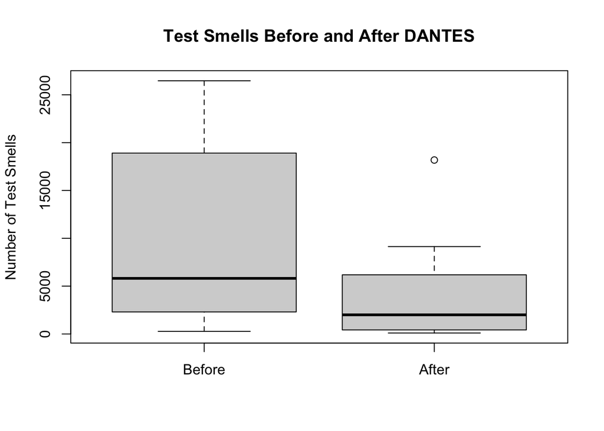

```r
boxplot(
  before,
  after,
  names = c("Before", "After"),
  ylab = "Number of Test Smells",
  main = "Test Smells Before and After DANTES"
)
```